# R_ML_STAT_01

## 01 가설 검정하기

### 가설 검정의 단계

- (가) 가설 설정
- (나) 유의수준 설정
- (다) 검정방법 설정
- (라) P값 산출
- (마) P값 유의수준보다 큰지 작은지 확인
  - 귀무가설, 대립가설 중 채택

### 분석의 목표

동일한 지원자를 대상으로 다이어트 프로그램 수행 전/후 체중을 기록하여 이들 간의 평균 차이가 통계적으로 유의하게 차이가 존재하는지(다이어트 프로그램이 의미가 있는지) 알아보자.

### 01 데이터 확인

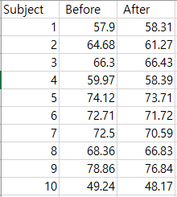

```r
data <- read.csv("../R_Data/diet.csv", header=T)
attach(data)
names(data)
```

```
## [1] "Subject" "Before"  "After"
```

```r
data
```

```
##    Subject Before After
## 1        1  57.90 58.31
## 2        2  64.68 61.27
## 3        3  66.30 66.43
## 4        4  59.97 58.39
## 5        5  74.12 73.71
## 6        6  72.71 71.72
## 7        7  72.50 70.59
## 8        8  68.36 66.83
## 9        9  78.86 76.84
## 10      10  49.24 48.17
```

### 02 검정 통계량 분포 확인 및 p-value 값 계산

- 우리는 우선 검정통계량을 결정
- 한 집단의 평균차이가 통계적으로 유의하게 차이가 존재하는지 알아봐야 하므로 동일한 집단의 두 평균 비교에 해당된다.
- 두 집단의 차의 평균이 0인지 아닌지를 확인한다.
- 앞서 살펴본 T검정 통계량을 바탕으로 t검정을 수행하여 p-값을 계산한다.

```r
library(ggplot2)
```

```r
diff <- Before - After
diff
```

```
##  [1] -0.41  3.41 -0.13  1.58  0.41  0.99  1.91  1.53  2.02  1.07
```

### (1) 다이어트 전후 차이에 대한 확인

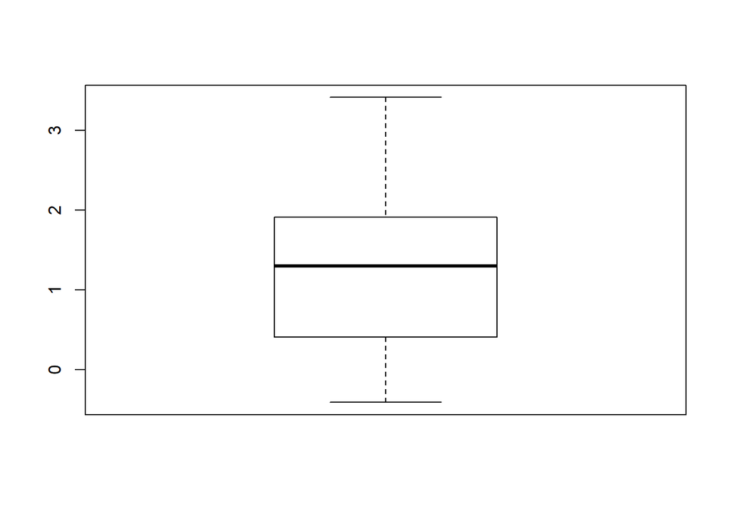

```r
boxplot(diff)
```

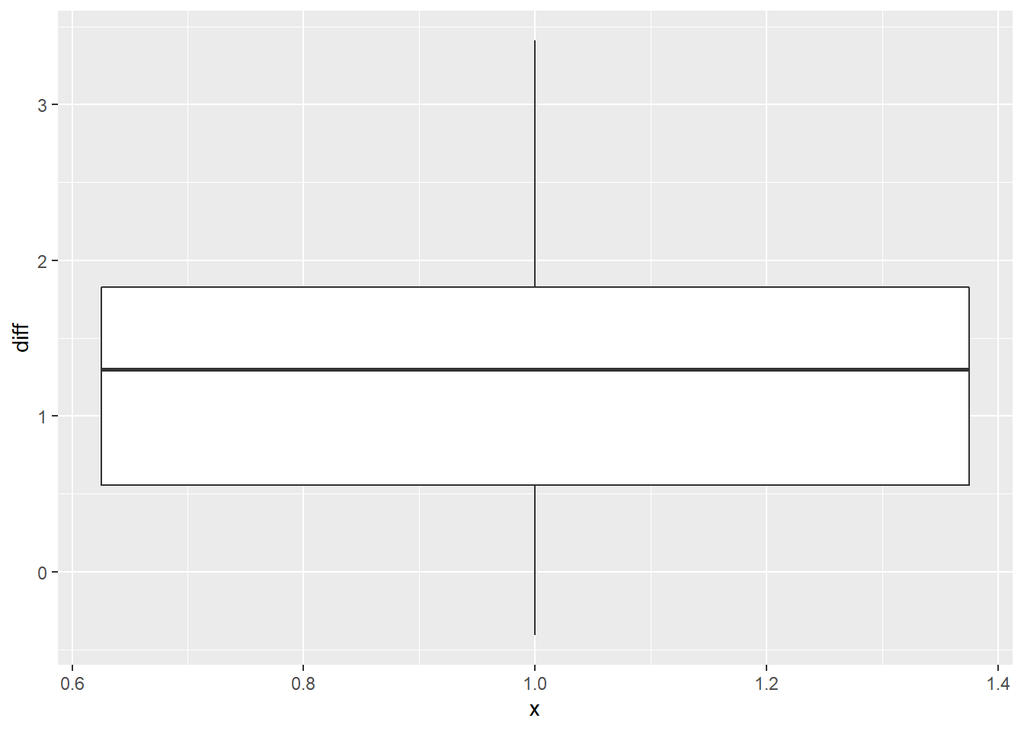

```r
ggplot(data, aes(x=1, y=diff)) + geom_boxplot()
```

### (2) T 통계량 계산하기

- 1. 각각의 차에 대한 평균 구하기
- 2. 표준 편차 구하기
- 3. 검정 통계량 계산하기

```r
mean_diff <- mean(diff)
mean_diff
```

```
## [1] 1.238
```

```r
sd_diff <- sd(diff)
sd_diff
```

```
## [1] 1.122772
```

```r
t_stat <- mean_diff/(sd_diff/sqrt(length(diff)))
t_stat
```

```
## [1] 3.486815
```

### (3) 양측검정

- 양측검정은 기각역이 양쪽 끝으로 나누어져 있음.

```r
t.test(Before, After, alternative=c("two.sided"), paired=TRUE, conf.level=0.95)
```

```
##
##  Paired t-test
##
## data:  Before and After
## t = 3.4868, df = 9, p-value = 0.006864
## alternative hypothesis: true difference in means is not equal to 0
## 95 percent confidence interval:
##  0.434817 2.041183
## sample estimates:
## mean of the differences
##                   1.238
```

### (4) 단측검정

- 기각역이 데이터의 상위 혹은하위꼬리 한쪽에만 존재.

```r
t.test(Before, After, alternative=c("greater"), paired=TRUE, conf.level=0.95)
```

```
##
##  Paired t-test
##
## data:  Before and After
## t = 3.4868, df = 9, p-value = 0.003432
## alternative hypothesis: true difference in means is greater than 0
## 95 percent confidence interval:
##  0.58715     Inf
## sample estimates:
## mean of the differences
##                   1.238
```

### 03 귀무가설 채택 및 검정

#### (A) 유의수준과 p-value를 활용하여 채택 여부를 결정한다.

#### (B) 양측검정, 단측검정 모두 p-value값이 유의수준보다 작다.

#### (C) 유의수준 5% 기준으로 귀무가설을 기각하고 대립가설을 채택한다.

#### (D) 가설검정을 통해 다이어트 프로그램이 체중 감소 효과가 있음을 알 수 있음.